# Homework 5

### Exercise 3

Perform an initial split of the data. Stratify by the outcome variable. You can choose a proportion to use. Verify that your training and test sets have the desired number of observations.

```r
set.seed(3435)
pokemon_split <- initial_split(pokemon, prop = 0.7, strata = type_1)
pokemon_train <- training(pokemon_split)
pokemon_test <- testing(pokemon_split)
dim(pokemon_train)
```

```
## [1] 318  13
```

```r
dim(pokemon_test)
```

```
## [1] 140  13
```

*Any reasonable proportion is fine here, as long as there are more observations in the training set than in testing, and there are some observations in both.*

Next, use *v*-fold cross-validation on the training set. Use 5 folds. Stratify the folds by `type_1` as well. *Hint: Look for a `strata` argument.* Why might stratifying the folds be useful?

```r
set.seed(3435)
pokemon_folds <- vfold_cv(data = pokemon_train, v = 5, strata = type_1)
```

*Stratifying the folds can be useful for the same reason stratifying the initial split can be/is; because it makes sure the distribution of a specified variable (often the outcome) remains the same across resamples or, in cross-validation, across folds.*

### Exercise 4

Set up a recipe to predict `type_1` with `legendary`, `generation`, `sp_atk`, `attack`, `speed`, `defense`, `hp`, and `sp_def`.

- Dummy-code `legendary` and `generation`;
- Center and scale all predictors.

```r
pokemon_recipe <- recipe(type_1 ~ legendary + generation +
                           sp_atk + attack + speed + defense +
                           hp + sp_def, data = pokemon_train) %>%
  step_dummy(all_nominal_predictors()) %>%
  step_normalize(all_predictors())
```

### Exercise 5

We’ll be fitting and tuning an elastic net, tuning `penalty` and `mixture` (use `multinom_reg` with the `glmnet` engine).

Set up this model and workflow. Create a regular grid for `penalty` and `mixture` with 10 levels each; `mixture` should range from 0 to 1. For this assignment, we’ll let `penalty` range from -5 to 5 (it’s log-scaled).

```r
elastic_net_spec <- multinom_reg(penalty = tune(),
                                 mixture = tune()) %>%
  set_mode("classification") %>%
  set_engine("glmnet")

en_workflow <- workflow() %>%
  add_recipe(pokemon_recipe) %>%
  add_model(elastic_net_spec)

en_grid <- grid_regular(penalty(range = c(-5, 5)),
                        mixture(range = c(0, 1)), levels = 10)
```

How many total models will you be fitting when you fit these models to your folded data?

*We’re fitting a grid of 100 combinations of values for the hyperparameters `penalty` and `mixture`, or 100 models, and we’re fitting each of these once per fold, for a total of 500 models.*

### Exercise 6

Fit the models to your folded data using `tune_grid()`.

```r
tune_res <- tune_grid(
  en_workflow,
  resamples = pokemon_folds,
  grid = en_grid
)
```

Use `autoplot()` on the results. What do you notice? Do larger or smaller values of `penalty` and `mixture` produce better accuracy and ROC AUC?

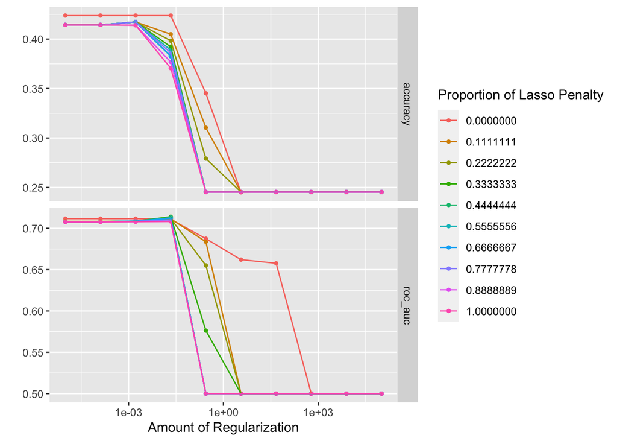

```r
autoplot(tune_res)
```

*Smaller values of penalty, or “amount of regularization,” and smaller values of mixture, or “proportion of lasso penalty,” tend to result in higher ROC-AUC and accuracy values. Answers here can vary, but aren’t required to get more detailed/specific than this.*

### Exercise 7

Use `select_best()` to choose the model that has the optimal `roc_auc`. Then use `finalize_workflow()`, `fit()`, and `augment()` to fit the model to the training set and evaluate its performance on the testing set.

```r
best_model <- select_best(tune_res, metric = "roc_auc")

en_final <- finalize_workflow(en_workflow, best_model)

en_final_fit <- fit(en_final, data = pokemon_train)

predicted_data <- augment(en_final_fit, new_data = pokemon_test) %>%
  select(type_1, starts_with(".pred"))
```

### Exercise 8

Calculate the overall ROC AUC on the testing set.

```r
predicted_data %>% roc_auc(type_1, .pred_Bug:.pred_Water)
```

```
## # A tibble: 1 × 3
##   .metric .estimator .estimate
##   <chr>   <chr>          <dbl>
## 1 roc_auc hand_till      0.721
```

Then create plots of the different ROC curves, one per level of the outcome. Also make a heat map of the confusion matrix.

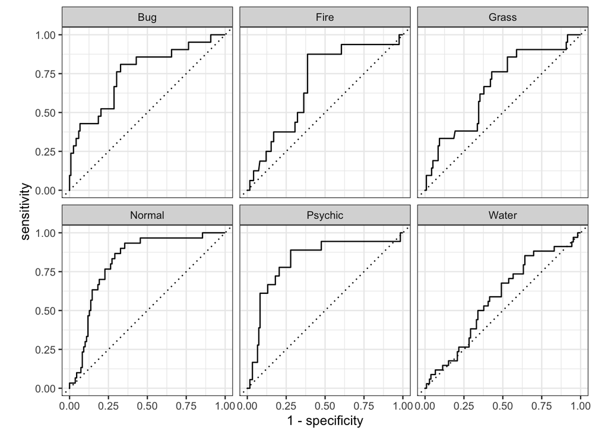

```r
predicted_data %>% roc_curve(type_1, .pred_Bug:.pred_Water) %>%
  autoplot()
```

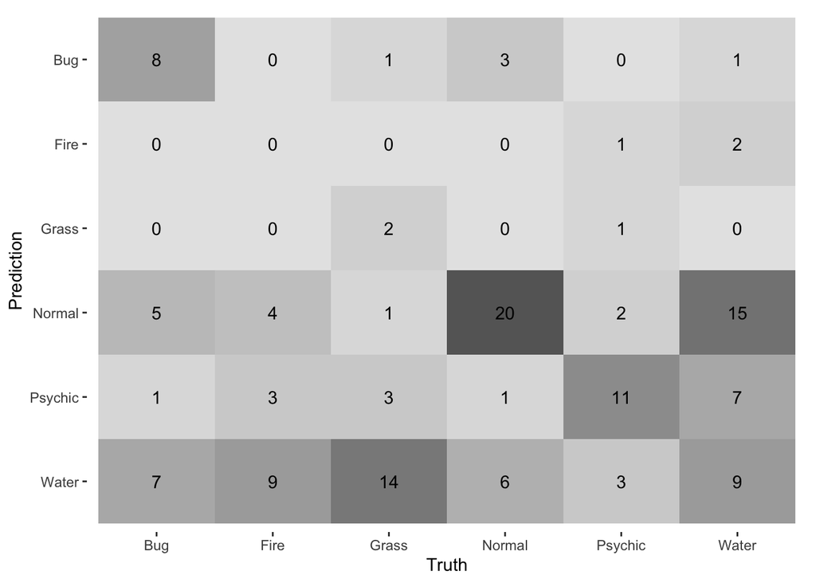

```r
predicted_data %>%
  conf_mat(truth = type_1, estimate = .pred_class) %>%
  autoplot(type = "heatmap")
```

What do you notice? How did your model do? Which Pokemon types is the model best at predicting, and which is it worst at? Do you have any ideas why this might be?

*Answers here may vary, depending on students’ interpretation and also on variation in model results. In other words, because of random sampling in the initial split and in the cross-validation (unless the exact same seed was set), values will differ.*

*Students should note the classes that their model is worst at differentiating; here, the model is worst at identifying Grass- and Water-type, based on the ROC curves. They should also identify those it’s best at; here that appears to be Psychic- and Normal-type.*

*Students aren’t required to speculate as to why this might be, but if they do, any answers are fine. Personal theory is that the stats themselves may not differentiate type very well, but learned moves might work as better predictors.*

## For 231 Students

### Exercise 9

In the 2020-2021 season, Stephen Curry, an NBA basketball player, made 337 out of 801 three point shot attempts (42.1%). Use bootstrap resampling on a sequence of 337 1’s (makes) and 464 0’s (misses). For each bootstrap sample, compute and save the sample mean (e.g. bootstrap FG% for the player). Use 1000 bootstrap samples to plot a histogram of those values. Compute the 99% bootstrap confidence interval for Stephen Curry’s “true” end-of-season FG% using the quantile function in R. Print the endpoints of this interval.

```r
steve_curry <- c(rep(1, 337), rep(0, 464))
```

*There may be multiple ways to solve this problem. One is to use a loop to generate the bootstrap samples:*

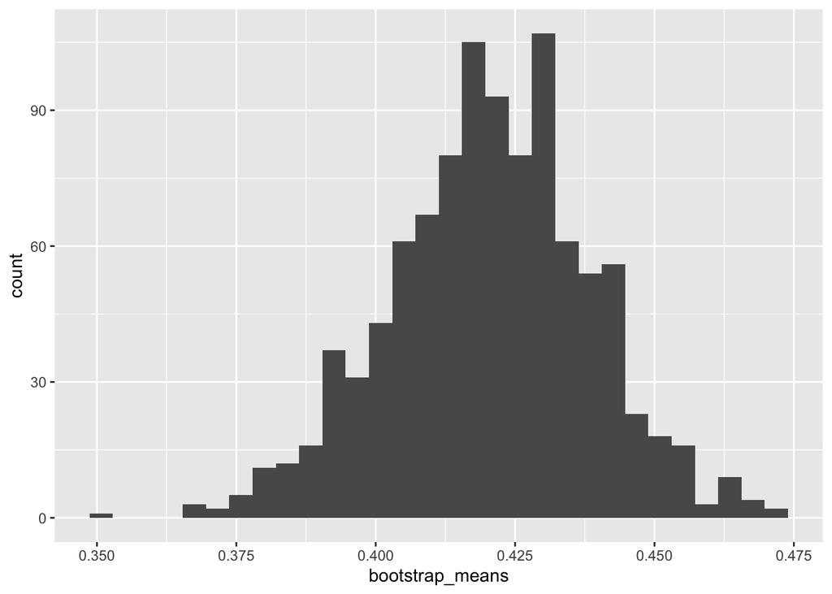

```r
bootstrap_means <- NULL # Setting up an empty object to store samples
set.seed(3435)

for(i in 1:1000){ # Doing this for 1000 samples
  boot_sample <- sample(steve_curry, replace = T) # The sampling
  bootstrap_means[i] <- mean(boot_sample) # Storing the mean of each sample
}

data <- tibble(bootstrap_means)

ggplot(aes(x = bootstrap_means),
       data = data) + geom_histogram()
```

*Here is a histogram of the values. It’s centered approximately around 0.42, which is what would be expected. To get a $99\%$ confidence interval from this distribution, we can ask for the distribution’s $0.005$ and $0.995$ quantiles:*

```r
quantile(bootstrap_means, c(0.005, 0.995))
```

```
##      0.5%     99.5%
## 0.3707865 0.4669164
```

*And the $99\%$ confidence interval for Curry’s “true” end-of-season FG% is from $0.37$ to $0.47$. Note that these numbers will differ unless students set the same seed; this is an artifact of random sampling and is fine.*